# La Data Visualisation outil de performance

## R Markdown

Ce tutoriel que nous allons traiter, nous permettra de voir l’importance de la Data Visualisation lors de nos études de données. Je souhaite montrer son impact et son apport par rapport aux outils traditionnels. quoi de mieux que d’utiliser le dataset nommée *Anscombe* présent dans la libraire R avec son quatuor pour expliquer l’apport de la Data visualisation, en terme de rapidité et de précision.

Ce dataset est un ensemble de quatre ensembles de données bidimensionnels de 11 lignes qui ont des propriétés statistiques similaires, mais des histoires apparemment différentes!. Nous voulons comprendre l’assertion ci-dessus, donc démontrer comment cela est possible.

```r
# visualisation et dplyr
library(tidyverse)
# Pour utiliser la fonction dcast lors de la régression linéaire
library(reshape2)
```

### Récupérons le dataset anscombe pour notre analyse

```r
anscombe <- datasets::anscombe
```

### Nom des colonnes

```r
names(anscombe)
```

```
## [1] "x1" "x2" "x3" "x4" "y1" "y2" "y3" "y4"
```

### Visualisons les données de notre dataframe (On sait que nous avons 11 observations)

```r
head(anscombe,11)
```

```
##    x1 x2 x3 x4    y1   y2    y3    y4
## 1  10 10 10  8  8.04 9.14  7.46  6.58
## 2   8  8  8  8  6.95 8.14  6.77  5.76
## 3  13 13 13  8  7.58 8.74 12.74  7.71
## 4   9  9  9  8  8.81 8.77  7.11  8.84
## 5  11 11 11  8  8.33 9.26  7.81  8.47
## 6  14 14 14  8  9.96 8.10  8.84  7.04
## 7   6  6  6  8  7.24 6.13  6.08  5.25
## 8   4  4  4 19  4.26 3.10  5.39 12.50
## 9  12 12 12  8 10.84 9.13  8.15  5.56
## 10  7  7  7  8  4.82 7.26  6.42  7.91
## 11  5  5  5  8  5.68 4.74  5.73  6.89
```

### Créons un nouveau dataframe regroupant les données de notre dataset anscombe en 4 groupe

```r
# Les x dans une colonne et les Y dans une autre.
dataframe_group <- data.frame(
    group  = rep(1:4, each = 11),
    x = unlist(anscombe[,c(1:4)]),
    y = unlist(anscombe[,c(5:8)])
    )
# on va ici ne pas nommer les lignes
rownames(dataframe_group) <- NULL

# Affichage du nouveau dataframe groupé segmenté en 4 groupes
head(dataframe_group,51)
```

```
##    group  x     y
## 1      1 10  8.04
## 2      1  8  6.95
## 3      1 13  7.58
## 4      1  9  8.81
## 5      1 11  8.33
## 6      1 14  9.96
## 7      1  6  7.24
## 8      1  4  4.26
## 9      1 12 10.84
## 10     1  7  4.82
## 11     1  5  5.68
## 12     2 10  9.14
## 13     2  8  8.14
## 14     2 13  8.74
```

[output cut: 30 more lines]

### Etudes statistiques de chacun de ces 4 groupes et comparons les résultats

*Moyenne par groupe*

```r
moyenne_par_groupe <- aggregate(dataframe_group, by = list(dataframe_group$group), FUN = mean)
moyenne_par_groupe[,c(1,4)]
```

```
##   Group.1        y
## 1       1 7.500909
## 2       2 7.500909
## 3       3 7.500000
## 4       4 7.500909
```

*Moyenne,Variance,Correlation par groupe*

```r
summary <-  dataframe_group %>% group_by(group) %>% summarize("moyenne x" = mean(x),
                                       "variance x" = var(x),
                                       "moyenne y" = round(mean(y),2),
                                       "variance y" = round(var(y),1),
                                       'Correlation(x,y)' = round(cor(x,y),2))
summary
```

```
## # A tibble: 4 x 6
##   group `moyenne x` `variance x` `moyenne y` `variance y` `Correlation(x,y~
##   <int>       <dbl>        <dbl>       <dbl>        <dbl>             <dbl>
## 1     1           9           11         7.5          4.1              0.82
## 2     2           9           11         7.5          4.1              0.82
## 3     3           9           11         7.5          4.1              0.82
## 4     4           9           11         7.5          4.1              0.82
```

*Regression Linéaire par groupe*

```r
modeles <- dataframe_group %>% group_by(group) %>% do(mod = lm(y ~ x, data = .)) %>% do(data.frame(var = names(coef(.$mod)),
                    coef = round(coef(.$mod),2),
                    group = .$group)) %>% dcast(., group~var, value.var = "coef")

summary_stats_and_linear_fit = cbind(summary, data_frame("Linear regression" =
                                    paste0("y = ",modeles$"(Intercept)"," + ",modeles$x,"x")))
summary_stats_and_linear_fit[,c(1,7)]
```

```
##   group Linear regression
## 1     1      y = 3 + 0.5x
## 2     2      y = 3 + 0.5x
## 3     3      y = 3 + 0.5x
## 4     4      y = 3 + 0.5x
```

**conclusion de notre analyse sans visualisation:** *D’après ce qui précède on peut dire que les 4 groupes sont plus ou moins identique.*

### Analysons maintenant les données des ces 4 groupes par la **visualisation**

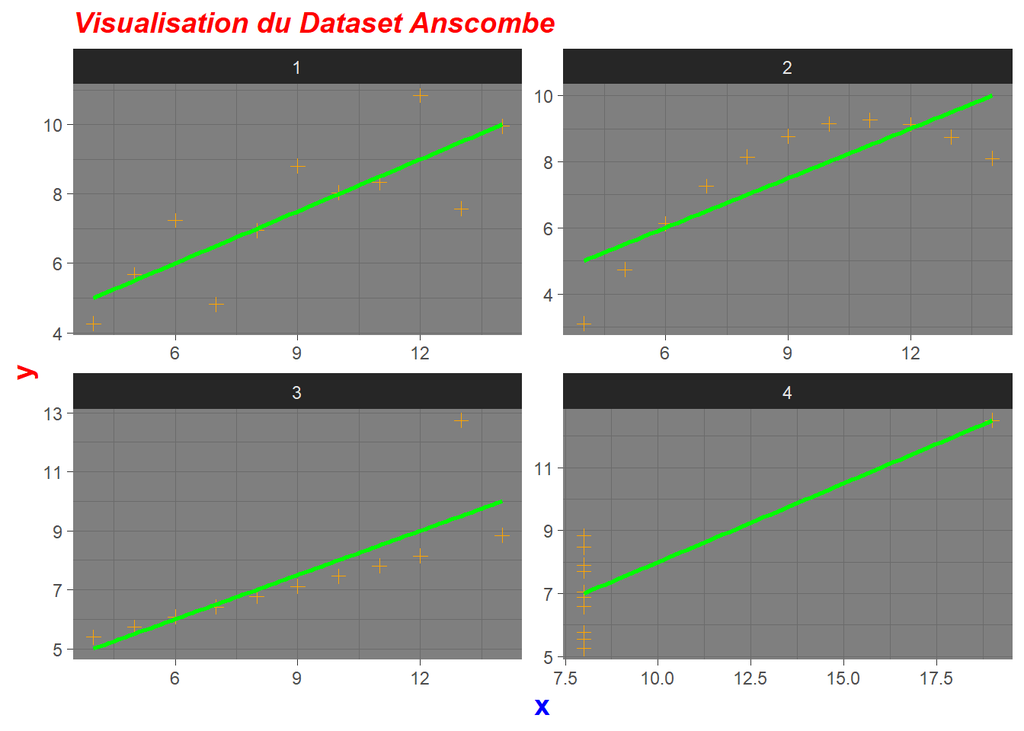

```r
graphe <- ggplot(dataframe_group, aes(x = x,y = y)) +
  geom_point(shape = 3, colour = "orange", size = 2) +
  ggtitle("Visualisation du Dataset Anscombe") +
  geom_smooth(method = "lm",se = FALSE,color = 'green') +
  facet_wrap(~group, scales="free") +
  theme_dark() +
  theme(plot.title = element_text(color = "red", size=14, face="bold.italic"),
        axis.title.x = element_text(color = "blue", size = 14, face = "bold"),
        axis.title.y = element_text(color = "red", size = 14, face = "bold"))

plot(graphe)
```

- Le graphe 1 nous montre que les données sont clairement linéaire
- Le graphe 2 est purement quadratique, les données forment une forme de courbe
- Le graphe 3 a une valeur aberrante que l’analyse ne nous a pas montré
- Le graphe 4 a une valeur aberrante très éloigné des autres et qui peut gravement fausser une interprétation.

**conclusion de notre analyse avec visualisation :** *Nous pouvons remarquer d’après ce qui précède, que les groupes sont très différents, ce ne que nous montrait pas particulièrement pas l’analyse par des outils statistiques. C’est la raison pour laquelle le Dataset “anscombe” est un puissant exemple qui permet de démontrer le fort impact de la data visualisation lors des analyses, que ce soit pour montrer des corrélations, des différences, des valeurs aberrantes dont on pourrait par exemple se soustraire pour l’application des techniques de Machine Learning.*

# Conclusion

**Nous pouvons donc conclure que la datavisualisation est bien un outil de performance qui nous permet de voir ce que les analyses traditionnelles ne nous permettent pas de voir.** **Nous devons de ce fait visualiser et comprendre ce que montre les données avant de faire tout analyses, au risque de faillir sur les interprétations. Un peu comme avec le paradoxe de Simpson que j’ai tenté d’expliquer dans un autre tutoriel.**